# Shubham Zod_38A_RTSM_Time Series Analysis_CEAT LTD Stock price analysis

Forecasting Considerations: When applying forecasting models to the differenced time series data, analysts can have confidence that the residuals are not systematically correlated with each other. This enhances the reliability of forecasts generated using the data.

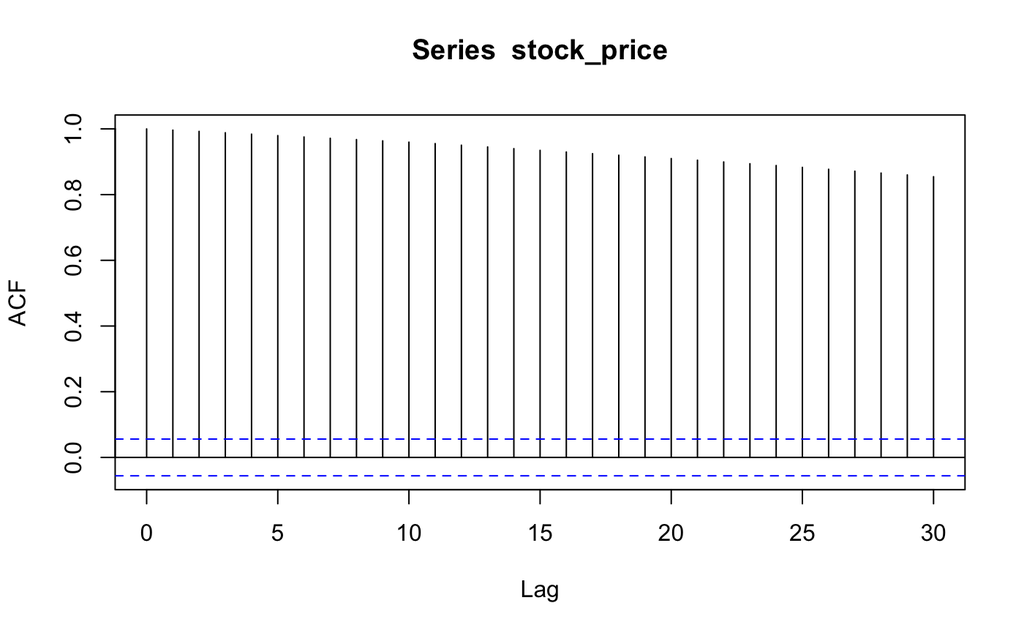

```r
# 3.0.3.2. Autocorrelation Function (ACF) | Partial Autocorrelation Function (PACF)
# *****************************************************************************

acf(stock_price) # ACF of JJ Series
```

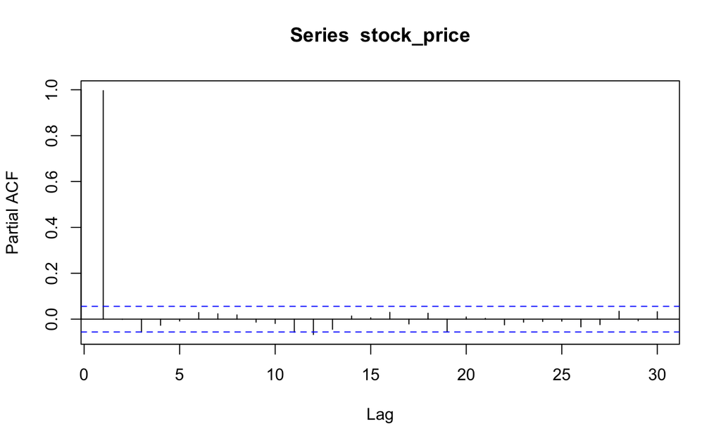

```r
pacf(stock_price) # PACF of JJ Series
```

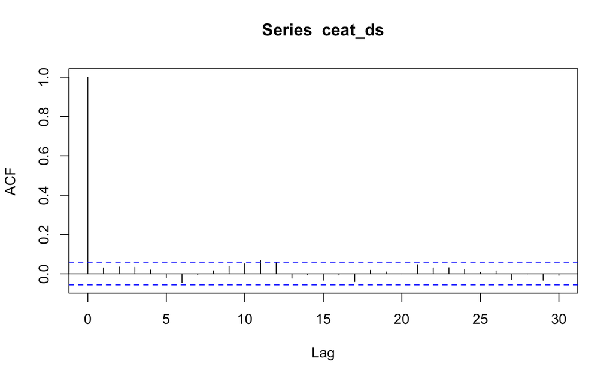

```r
acf(ceat_ds) # ACF of CEAT Difference (Stationary) Series
```

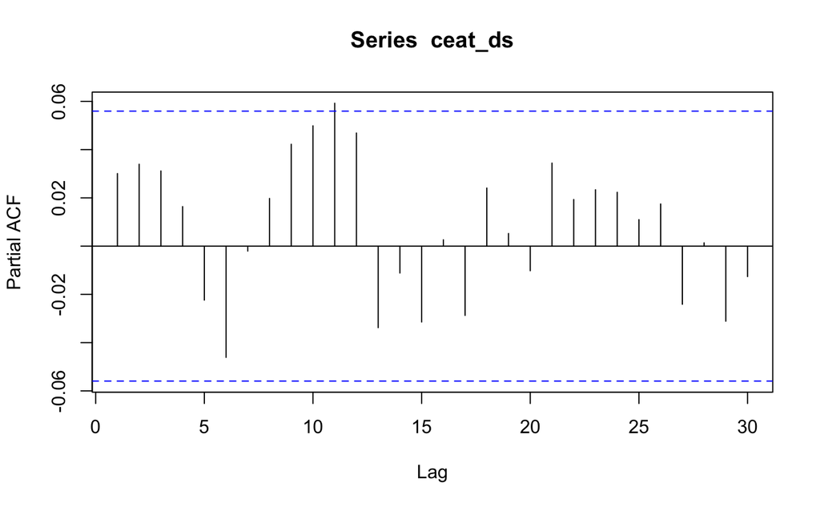

```r
pacf(ceat_ds) # PACF of CEAT Difference (Stationary) Series
```

The code computes and plots the Autocorrelation Function (ACF) and Partial Autocorrelation Function (PACF) for two different series:

For the CEAT stock price data (stock_price):

acf(stock_price) computes and plots the ACF of the CEAT stock price series. pacf(stock_price) computes and plots the PACF of the CEAT stock price series. For the differenced (stationary) CEAT stock price data (ceat_ds):

acf(ceat_ds) computes and plots the ACF of the differenced CEAT stock price series. pacf(ceat_ds) computes and plots the PACF of the differenced CEAT stock price series.

These plots provide insights into the autocorrelation and partial autocorrelation structures of the respective time series data, which are essential for identifying the orders of autoregressive (AR) and moving average (MA) terms in ARIMA modeling.

```r
# 3.1. Auto Regressive Integrated Moving Average (ARIMA) Models
# *************************************************************

# 3.1.1. ARIMA Models
# *******************

# AR (p-Lag) Model : y(t) = c1 + a1*y(t-1) + a2*y(t-2) + ... + ap*y(t-p) + e(t) where e = error == White Noise | AR-1 Model : y(t) = c + a1*y(t-1) + e(t)
# MA (q-Lag) Model : y(t) = c2 + b1*e(t-1) + b2*e(t-2) + ... + bp*e(t-p) where e = Error == White Noise | MA-1 Model : y(t) = d + b1*e(t-1)
# ARMA (p, q) Model : y(t) = c + a1*y(t-1) + ... + ap*y(t-p) + b1*e(t-1) + ... + bp*e(t-p) + e(t) | ARMA (1, 1) Model : y(t) = c + a1*y(t-1) + b1*e(t-1) + e(t)

# ARIMA(p, d, q) = AR Order (p-Lags) | d-Degree of Differencing | MA Order (q-Lags)

# Note: The Degree of Differencing for a Time Series data such as Asset Returns is d=0. For a Time Series data such as Asset Prices the Degree of Differencing is usually d=1.
# Identify AR Order : PACF Cuts Off after p Lags | ACF Tails Off
# Identify MA Order : ACF Cuts Off after q Lags | PACF Tails Off
```

```r
arma_pq_ceat_ds = auto.arima(ceat_ds); arma_pq_ceat_ds #p-lag=2, q-lag=2
```

```
Series: ceat_ds
ARIMA(2,0,2) with zero mean

Coefficients:
         ar1      ar2      ma1     ma2
      1.2798  -0.8365  -1.2628  0.8624
s.e.  0.0845   0.0732   0.0729  0.0717

sigma^2 = 0.0004891:  log likelihood = 2937.59
AIC=-5865.19   AICc=-5865.14   BIC=-5839.62
```

The output from the auto.arima function suggests an ARIMA(2,0,2) model with zero mean for the differenced (stationary) CEAT stock price data (ceat_ds).

Detailed Analysis and Implications:

Model Interpretation: The ARIMA(2,0,2) model indicates that the current value of the differenced CEAT stock prices depends linearly on the two most recent values and the two most recent errors.

Coefficient Analysis: The estimated coefficients represent the strength and direction of the relationships between the current value of the series and its past values and errors.

Standard Errors: These values measure the uncertainty in the estimated coefficients. Lower standard errors suggest higher precision in the estimation.

Variance: The variance represents the dispersion of the errors around the fitted values. A lower variance indicates a better fit of the model to the data.

Information Criteria (AIC, AICc, BIC): These criteria provide measures of the relative quality of different statistical models. Lower values indicate a better trade-off between model fit and complexity.

Forecasting: The ARIMA(2,0,2) model can be used for forecasting future values of the differenced CEAT stock prices. However, it’s essential to validate the model’s performance and assess its predictive accuracy before using it for actual forecasts.

In summary, the ARIMA(2,0,2) model provides a statistical framework for analyzing and forecasting the differenced CEAT stock prices. Careful interpretation of the coefficients and model diagnostics is crucial for making informed decisions in time series analysis and forecasting.

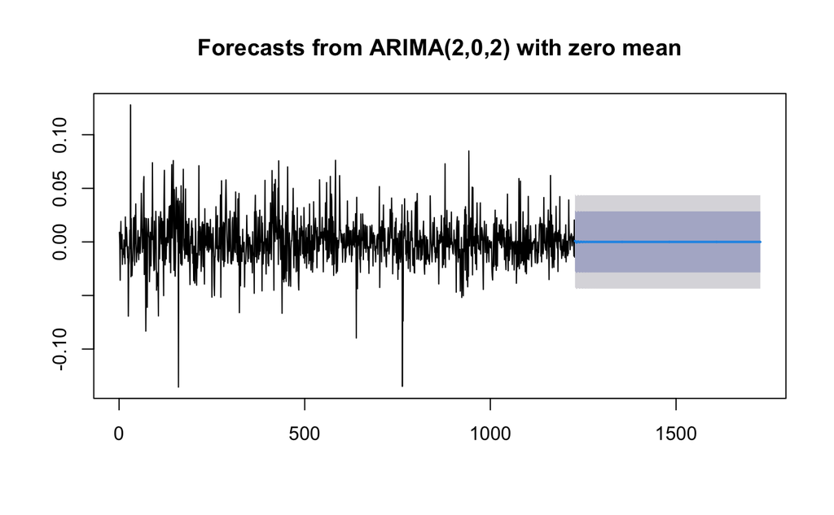

```r
ceat_ds_fpq = forecast(arma_pq_ceat_ds, h = 500)
plot(ceat_ds_fpq)
```

The code generates forecasts for the differenced (stationary) CEAT stock price data (ceat_ds) using the ARIMA(2,0,2) model (arma_pq_ceat_ds) previously fitted. It then plots the forecasted values.

This code segment computes forecasts for 500 future time points based on the ARIMA(2,0,2) model fitted to the differenced CEAT stock price data and visualizes these forecasted values in a plot.

```r
# Ljung-Box Test for Autocorrelation - Model Residuals
# ****************************************************

lb_test_arma_pq_ceat_ds = Box.test(arma_pq_ceat_ds$residuals); lb_test_arma_pq_ceat_ds
```

```
    Box-Pierce test

data:  arma_pq_ceat_ds$residuals
X-squared = 0.042871, df = 1, p-value = 0.836
```

```r
#p-value>alpha
```

The Box-Pierce test examines autocorrelation in the residuals of the ARIMA(2,0,2) model applied to the differenced CEAT stock price data (arma_pq_ceat_ds$residuals). The results are as follows:

Test Statistic (X-squared): 0.042871 Degrees of Freedom (df): 1 p-value: 0.836 With a p-value of 0.836, which is substantially greater than the conventional significance level of 0.05, there isn’t adequate evidence to reject the null hypothesis. Hence, we do not identify significant autocorrelation in the residuals of the ARIMA(2,0,2) model.

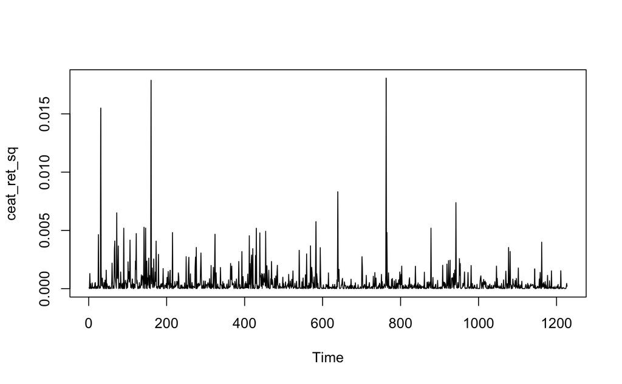

```r
# Test for Volatility Clustering or Heteroskedasticity: Box Test
ceat_ret_sq = arma_pq_ceat_ds$residuals^2 # Residual Variance (Since Mean Returns is approx. 0)
plot(ceat_ret_sq)
```

```r
ceat_ret_sq_box_test = Box.test(ceat_ret_sq, lag = 2) # H0: Return Variance Series is Not Serially Correlated
ceat_ret_sq_box_test # Inference : Return Variance Series is Autocorrelated (Has Volatility Clustering)
```

```
    Box-Pierce test

data:  ceat_ret_sq
X-squared = 9.0038, df = 2, p-value = 0.01109
```

The code segment conducts a Box test to assess the presence of volatility clustering or heteroskedasticity in the CEAT stock returns. Here’s a detailed analysis of the output:

Test Statistic (X-squared): The Box test statistic is calculated to be 9.0038. Degrees of Freedom (df): The test has 2 degrees of freedom. p-value: The p-value obtained from the test is 0.01109. With a p-value of 0.01109, which is less than the conventional significance level of 0.05, we reject the null hypothesis. Therefore, the inference is that the return variance series exhibits autocorrelation or volatility clustering, indicating the presence of heteroskedasticity in the CEAT stock returns.